# Clean 1 - data wrangling

TG

2024-1-11

# In this script:

1. Input of 2 raw data set (2 data frames, Medata and complexity data from the `raw input data` folder)
- Optional addition of Lisandro data (need to decide if we are using them), data = `medata_raw_lis`, see script `Lisandro data addition`
2. Clean and organize, set the basin, verify MPA Classification, remove sites that should be ommited ect.
3. Set the pairs of MPA and control sites
4. Output - 4 processed dataframes saved to the `clean output data` folder
- `Clean_Medata.Rdata` - the clean MeData after all the alternations

*`Clean_Medata_lis.Rdata` - the clean MeData after all the alternations including Lisandro data

- `unique_coords.Rdata` - dataframe with distinct survey locations
- `pairs.Rdata` - dataframe all the MPA and control sites
- `Clean_complexity_data.Rdata` - the clean complexity data

# MeData dataframe

load the original data as download from github at 15.1.2023

Alternatively - load the data including Lisandro transects

```r
medata_raw <- readRDS("G:\\My Drive\\PHD\\chapter 3 MPA dd\\Meddata-DD\\raw input data\\medata_from_git_after_cyp.Rds")


load("G:\\My Drive\\PHD\\chapter 3 MPA dd\\Meddata-DD\\clean output data\\medata_raw_lis.Rdata")

medata<-medata_raw_lis # the version ill play with
```

## Data cleaning

Remove transects that have only 0 and seems like mistakes (could happened when using Acess to upload the data, you cannot delete false observation just to change to 0)

```r
transect_to_remove<-c("kornati217015286494381202NA",
                      "kornati216815286494381202NA",
                      "kornati216915286494381202NA",
                      "gdor164534866923241672NA")

medata<-medata %>% filter(!unique_trans_id %in% transect_to_remove)


rm(transect_to_remove)
```

Examine the species list:

```r
species<- medata %>% distinct(species)
```

Remove `.spp` species:

```r
Species_to_remove <-species$species[which(str_detect(species$species,".spp")==T)]

Species_to_remove
```

```
## [1] "Symphodus.spp" "Atherina.spp"  "Scorpaena.spp" "Sphyraena.spp"
## [5] "Gobius.spp"    "Trachinus.spp" "Spicara.spp"   "Dasyatis.spp"
```

```r
medata <-medata %>% filter(!species %in% Species_to_remove)

rm(Species_to_remove)
```

Remove cryptic species:

Gobiidae, Blenniidae & Tripterygiidae

```r
Families_to_remove<- c("Gobiidae","Blenniidae","Tripterygiidae")

medata <-medata %>% filter(!family %in% Families_to_remove)

species<- medata %>% distinct(species,family) # Make sure manually that all species and family are correct

rm(Families_to_remove)
```

## fix cyprus coords

The lat and lon of Cyprus are swapped (lon is under lat and vice-versa, fixed on git on latter additions)

```r
medata$lat_n<-ifelse(medata$country=="Cyprus",
                               medata$lon,
                               medata$lat)

medata$lon_n<-ifelse(medata$country=="Cyprus",
                              medata$lat,
                              medata$lon)

medata<-medata %>% dplyr::select(-lat,-lon) %>%
  rename("lat" = "lat_n","lon" = "lon_n") %>%
  relocate(lat, .after = season) %>%
  relocate(lon,.before = site)

medata<-medata %>% drop_na(protection)
```

## Add banyuls coordinates

```r
Banyuls_location <- read.csv("raw input data\\Banyuls location.csv")
Banyuls_location <- Banyuls_location %>%  select(site,Latitude,Longitude)

medata<-left_join(medata,Banyuls_location)
medata$lat<-ifelse(medata$country=="France",medata$Latitude,medata$lat)
medata$lon<-ifelse(medata$country=="France",medata$Longitude,medata$lon)


medata$Latitude<-NULL
medata$Longitude<- NULL

rm(Banyuls_location)
```

## basin classifications

load general Mediterranean map to determine which points belongs to each basin polygon

```r
med_seas <- st_read("Med_World_Seas_IHO_v3_MarineRegions/Medit_seas_IHO.shp")
```

To determine which transect belongs to which basin we apply this loop that also provide small buffer around the basins so no transect will fall on land.

```r
# Assuming 'med_seas' is your sf object

med_seas_sf <- st_as_sf(med_seas)

# Initialize an empty sf object to store the results with the same structure as med_seas

for (i in 1:nrow(med_seas_sf)) {

  region <- med_seas_sf[i,]  # Select each region
  region_bf <- st_buffer(region, dist = 0.01)  # Make a buffer around the region, unit is degree because the crs is wgs84
  other_regs <- med_seas_sf[-i,]  # Select all other regions
  union_other_regs <- st_union(other_regs)

  union_other_regs <- st_combine(union_other_regs)

  region_bf_land <- st_difference(region_bf, union_other_regs)  # Delete overlapping parts with other regions
  #region_bf_land <- region_bf_land # Keep only the one without overlaps

 if(i == 1){
    med_seas_bf <- region_bf_land # for the first loop
  }else{
    med_seas_bf <- bind_rows(med_seas_bf, region_bf_land) # for the other loop itr
  }
  print(i)
}
```

```
## [1] 1
## [1] 2
## [1] 3
## [1] 4
## [1] 5
## [1] 6
## [1] 7
## [1] 8
## [1] 9
## [1] 10
## [1] 11
```

```r
# Make sure all the geometry is valid

med_seas_bf_valid <- st_make_valid(med_seas_bf)

# convert medata to spatial object

medata_sf <- st_as_sf(medata, coords = c("lon", "lat"))

# Make sure both datasets have the same coordinate reference system (CRS)

medata_sf <- st_set_crs(medata_sf, st_crs(med_seas_bf_valid))

# Perform spatial join

medata_sf <- st_join(medata_sf, med_seas_bf_valid)

# Now 'medata_sf' contains the attributes from 'med_seas_bf' matched to each point

# If you want to create a new column 'Basin' in 'medata_sf' with basin information
medata_sf$Basin <- medata_sf$NAME


medata_sf<-medata_sf %>% select(-c(27:36))

# If you want to create a new column 'colour' as an integer factor

medata_sf$colour <- as.integer(as.factor(medata_sf$Basin))

# Check for missing values in the 'Basin' column

unique(is.na(medata_sf$Basin))
```

```
## [1] FALSE
```

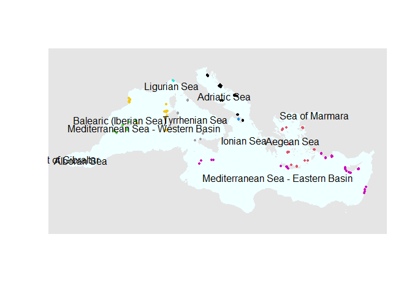

```r
# plot to see that all the point are correct

plot(st_geometry(med_seas), col = 'azure', border = NA, bg = 'grey90')
plot(medata_sf$geometry, add = T, pch = 19, cex = 0.5, col = medata_sf$colour)
text(med_seas_bf_valid$Longitude, y = med_seas_bf_valid$Latitude,med_seas_bf_valid$NAME)
```

Add the basin to the non-spatial MeData

```r
basin <-medata_sf

basin<-as.data.frame(basin)

basin <- basin %>%  dplyr::select(Basin,unique_trans_id) %>% distinct(unique_trans_id,.keep_all = T)

medata<-left_join(medata,basin)
medata<-medata %>% relocate(Basin,.after = country)
```

Clean enviorinment

```r
rm(list = setdiff(ls(), c("medata","medata_raw","medata_raw_lis","med_seas")))
```

Create alternative basin division which:

- Add the `Ionian Sea` to the `Adriatic Sea`
- Add the `Ligurian Sea` to the `Mediterranean Sea - Western Basin`
- Separate Israel to the `Levantine Sea`

```r
medata<-medata %>% mutate(alt_basin = Basin) %>% relocate(alt_basin,.after = Basin)

medata$alt_basin<-ifelse(medata$Basin == "Ionian Sea",
                         "Adriatic Sea",
                         medata$alt_basin)

medata$alt_basin<-ifelse(medata$Basin == "Ligurian Sea",
                         "Mediterranean Sea - Western Basin",
                         medata$alt_basin)

medata$alt_basin<-ifelse(medata$country %in% c("Israel"),
                         "Levantine Sea",
                         medata$alt_basin)
```

## unite close sites

```r
meta <- medata %>% select(1:20) %>% distinct(unique_trans_id,.keep_all = T)
```

get mean coordinate per site

```r
meta_site<- meta %>% group_by(alt_basin,site) %>% summarise(lat = mean(lat),lon = mean(lon))
```

- change all the ‘assecret’ sites to informative site names
- unite the names of close transects to have one site name

```r
new_name<-data.frame(site=c("assecret2010193","assecret2010192","assecret2010191","assecret1210192","assecret1210191"),
                     new_site_name = rep("Crete_Monoafitis"))


new_name_2<- data.frame(site=c("assecret1810193","assecret1810192","assecret1810191"),
                     new_site_name = rep("Crete_Paximadia"))

new_name_3<- data.frame(site=c("assecret1410193","assecret1610191","assecret1410192","assecret1410191",
                               "assecret1610192","assecret1610193"),
                     new_site_name = rep("Crete_Plakias"))


new_name_4<- data.frame(site=c("assecret2210191","assecret2210192"),
                     new_site_name = rep("Crete_Krios"))


new_name_5<- data.frame(site=c("assecret1910191","assecret1910193","assecret1910192","assecret1310192",
                               "assecret1310191","assecret1310193"),
                     new_site_name = rep("Crete_Kalydon"))


new_name_6<-data.frame(site = unique(medata$site[medata$country=="France"]),
                       new_site_name = "Banyuls")

new_name_7<-data.frame(site = c("asinara_add","Nisia"),
                       new_site_name = c("asinara","Kavo Gkreko"))

new_name <- rbind(new_name,new_name_2,new_name_3,new_name_4,new_name_5,new_name_6,new_name_7)



meta_site<-left_join(meta_site,new_name)

meta_site<-meta_site %>% mutate(new_site_name = case_when(is.na(new_site_name) ~ site,
                                   TRUE ~ new_site_name)) %>%

select(site,new_site_name)


medata<-left_join(medata,meta_site)

medata<-medata %>%
  relocate(new_site_name,.after = site)

medata$new_site_name<-as.factor(medata$new_site_name)
```

Remove `Crete_Kalydon` site where there is active feeding of groupers

```r
medata<-medata %>% filter(new_site_name !="Crete_Kalydon")
```

fix some point in Spain that needed to be added to the Balearic so all the transect in one site will belong to the same basin

```r
medata$alt_basin[medata$new_site_name=="cabrera"]<-"Balearic (Iberian Sea)"

medata$alt_basin[medata$new_site_name=="illa_de_l'aire"]<-"Balearic (Iberian Sea)"
```

change `TRUE` & `FALSE` variables

```r
medata$protection<-ifelse(medata$protection==TRUE,"Protected","Not protected")

medata$exotic<-ifelse(medata$exotic==TRUE,"Invasive","Native")
```

```r
rm(list = setdiff(ls(), c("medata","medata_raw","medata_raw_lis","med_seas")))
```

## fix enforcment levels

Adjust the enforcement levels of the Cyprus transects to fit the ms classification

reassessment was made by Dr.Periklis Kleitou experts team

```r
Cypurs_class<- read_csv("raw input data/Cypurs classification_MER.csv")
Cypurs_class <- Cypurs_class %>% select(lat_lon,classification,verified_classification)

medata<-medata %>% mutate("lat_lon" = paste(lat,lon,sep=","))

medata<-left_join(medata,Cypurs_class)
medata$enforcement<-as.character(medata$enforcement)

medata$enforcement<-ifelse(medata$country=="Cyprus",
                           medata$verified_classification,
                           medata$enforcement)

medata$enforcement<-as.numeric(medata$enforcement)

medata<-medata %>% select(1:30) # remove the additional columns

# fix cases when enforcement  = 0 but specify as Protected (due to score change in Cyprus)

medata$protection<-ifelse(medata$enforcement == 0,"Not protected",medata$protection)


rm(Cypurs_class)
```

## Study site map

get only distinct point with different lat and lon:

```r
unique_coords<-medata %>% distinct(lat,lon,enforcement,protection,.keep_all = T) %>% dplyr::select(country,new_site_name,lat,lon,protection,enforcement)
```

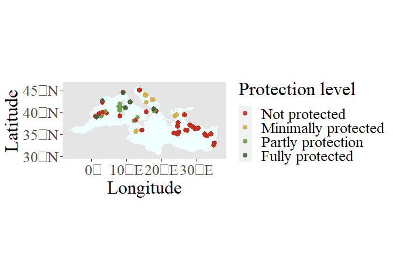

```r
unique_coords$enforcement<-as.character(unique_coords$enforcement)

ggplot(unique_coords) +
  geom_sf(data = med_seas$geometry, mapping = aes(),fill= "azure",color = NA) + ##D4ECFF
  geom_point(data =unique_coords,aes(x = lon, y = lat, color = enforcement),
             size = 2.5,alpha = 0.9,position=position_jitter(h=0.06, w=0.06)) +
  xlab("Longitude") +
  ylab("Latitude") +
  theme(panel.background = element_rect(fill = "grey90"),
        text=element_text(size=24, family = "serif"),
        panel.grid.major = element_line(colour = "transparent"))+
  scale_color_manual("Protection level",values=c("#C42E1C","#D4B04A","#70A34E","#446441"),
                     labels = c("Not protected",
                                "Minimally protected",
                                "Partly protection",
                                "Fully protected"))
```

## Interactive map:

```r
color_pal<- colorFactor(palette = c("#C42E1C","#D4B04A","#70A34E","#446441"), domain = unique_coords$enforcement,alpha = 0.5)


leaflet(unique_coords) %>%
  addTiles() %>%
  addCircles(lng=~lon,lat=~lat,radius = 50,color = ~color_pal(unique_coords$enforcement),
    stroke = T,label = ~as.character(new_site_name))
```

[interactive chart not shown]

some coloumn name changes

```r
medata<-medata %>% rename(Old_basin = Basin,
                          Old_site = site )

medata<-medata %>% rename(Basin = alt_basin,
                          Site = new_site_name)
```

### save medata

```r
# save(medata, file = "G:\\My Drive\\PHD\\chapter 3 MPA dd\\Meddata-DD\\clean output data\\Clean_Medata_lis.Rdata")

# write.csv(medata,"G:\\My Drive\\PHD\\chapter 3 MPA dd\\Meddata-DD\\clean output data\\Clean_Medata_lis.csv")
```

### save coordinate data

save the unique coordinates data

```r
#save(unique_coords,file = "G:\\My Drive\\PHD\\chapter 3 MPA dd\\Meddata-DD\\clean output data\\unique_coords_lis.Rdata")

#write.csv(unique_coords,"G:\\My Drive\\PHD\\chapter 3 MPA dd\\Meddata-DD\\clean output data\\unique_coords_lis.csv")
```

# Match pairs of MPA and control

In this section I’ll create data set that contained all the pairs of MPAs and control sites

MPA must be Fully (3) or Partly protected (2), control must be unprotected (0)

```r
pair_raw<-medata %>% select(1:23) # keep only metadate and abundances

pair_raw<-pair_raw %>% group_by(across(1:22)) %>% summarise(amount = sum(sp.n)) %>% ungroup() # sum the individuals from the same species in each transect
```

[output not shown]

```r
pair_raw<-spread(pair_raw,species,amount,fill = 0) # convert to wide format

pair_raw<-pair_raw %>% select(data.origin,country,Site,enforcement) %>% distinct(,.keep_all = T)
```

```r
site_list<-list()
```

#### Brijoni

In Croatia only Brijoni have pair of fully/partly MPA and control site

```r
Brijoni <- pair_raw %>% filter(Site == "brijuni")

Brijoni$pair<-"Brijoni"

Brijoni$Cluster<-rep(NA)

site_list[[1]]<-Brijoni

rm(Brijoni)
```

#### Israel

In Israel all MPAs beside `Habonim` have control sites

```r
isr<-pair_raw %>% filter(country == "Israel",Site != "habonim")

isr$pair<-isr$Site

isr$Cluster<-rep(NA)

site_list[[2]]<-isr

rm(isr)
```

#### France

only one MPA and control sites

```r
Banyuls <- pair_raw %>% filter(Site == "Banyuls")

Banyuls$pair <-"Banyuls"

Banyuls$Cluster<-rep(NA)

site_list[[3]]<-Banyuls

rm(Banyuls)
```

#### Spain

Multiple pairs of MPAs and control sites.

**Note** - there are two possible control sites for `Cabrera` MPA, I used `Dragonera` because it a bit closer and also an island and omit `formentor` *but* we might change it later or use 2 pairs (or aggregate the two control sites…)

**Note 2** - same goes for `cap_de_creus` - no pair so I ommited but we should talk to the team and see what they think. - add Monegri as control

```r
spain<-pair_raw %>% filter(country == "Spain")

spain <- spain %>% mutate(pair = case_when(
  Site == "formentera"~ "Formentera",
  Site == "eivissa"~ "Formentera",
  Site == "cabrera"~"Cabrera",
  Site == "dragonera"~ "Cabrera",
  Site == "cavalleria"~ "Cavalleria",
  Site == "illa_de_l'aire"~ "Cavalleria",
  Site == "medes"~ "Medes",
  Site == "montgri"~ "Medes",

  ))

spain<-spain %>% drop_na(pair)


spain_2<-pair_raw %>% filter(country == "Spain",Site %in% c("montgri","cap_de_creus"))

spain_2$pair = "Cap De Creus"

spain<-rbind(spain,spain_2)


spain$Cluster<-ifelse(spain$Site %in% c("montgri","cap_de_creus","medes"),"Medes-cap_de_creus",NA)


site_list[[4]]<-spain

rm(spain,spain_2)
```

#### Italy

Need to decide how to treat those 3 sites…

- I did two different comparison with `carloforta` as the control for both `tavolara` and `Asinara` MPAs.
- In `Asinara` some transect are full protected and some partly protected.
- I did not find control for `porto_cesareo` maybe i can use `otranto`- needs to check

```r
itl<-pair_raw %>% filter(country == "Italy",data.origin != "Belmaker")

itl <- itl %>% mutate(pair = case_when(
  Site == "portofino" ~ "Portofino",
  Site == "genova" ~ "Portofino",
  Site == "torre_guaceto" ~ "Torre guaceto",
  Site == "otranto" ~ "Torre guaceto",
  Site == "asinara" ~ "Asinara",
  Site == "carloforte" ~ "Asinara"))

itl<-itl %>% drop_na(pair)

itl_2<-pair_raw %>% filter(country == "Italy",Site %in% c("tavolara","carloforte"))

itl_2$pair = "Tavolara"

itl<-rbind(itl,itl_2)

itl_3<-pair_raw %>% filter(country == "Italy",Site %in% c("otranto","porto_cesareo"))

itl_3$pair = "Porto Cesareo"

itl<-rbind(itl,itl_3)


cls1<-c("otranto","porto_cesareo","torre_guaceto")
cls2<-c("tavolara","carloforte","asinara")

itl$Cluster<-ifelse(itl$Site %in% cls1,"Porto Cesareo - Torre_guaceto",NA)

itl$Cluster<-ifelse(itl$Site %in% cls2,"Tavolara - Asinara",itl$Cluster)

site_list[[5]]<-itl
```

Note - Combining the data later on using `left_join` will multiply the rows of `carloforte` so one time it paired with `tavolara` and one time with `Asinara`.

#### Cyprus

```r
cyprus <-pair_raw %>% filter(country == "Cyprus",
                             Site == "Kavo Gkreko",
                             enforcement !=1)

cyprus$pair<-"Kavo Gkreko"

cyprus$Cluster<-rep(NA)

site_list[[6]]<-cyprus

rm(cyprus)
```

#### Sicily

```r
Sicily <-pair_raw %>% filter(country == "Italy",
                            data.origin == "Belmaker")

Sicily_1<-Sicily %>% filter(Site %in% c("ustica","san_vito"))

Sicily_1$pair = "ustica"


Sicily_2<-Sicily %>% filter(Site %in% c("marettimo","san_vito"))

Sicily_2$pair = "marettimo"

Sicily<-rbind(Sicily_1,Sicily_2)

Sicily$Cluster<-rep("Ustica-Marettimo")

site_list[[7]]<-Sicily

rm(Sicily_1,Sicily_2,Sicily)
```

```r
pairs <- bind_rows(site_list)

rm(site_list,pair_raw)
```

```r
#save(pairs,file = "G:\\My Drive\\PHD\\chapter 3 MPA dd\\Meddata-DD\\clean output data\\pairs.Rdata")

#write.csv(pairs,"G:\\My Drive\\PHD\\chapter 3 MPA dd\\Meddata-DD\\clean output data\\pairs.csv")
```

# complexity data

```r
comp_data_raw <-read.csv("G:\\My Drive\\PHD\\chapter 3 MPA dd\\Meddata-DD\\raw input data\\Mediterranean_data_COMPLEX.csv")

lab_fish_data_raw <- read.csv("G:\\My Drive\\PHD\\chapter 3 MPA dd\\Meddata-DD\\raw input data\\Med_analyses_data.csv")

comp_data_raw$X<-NULL
lab_fish_data_raw$X<-NULL
```

unite data frames

```r
colnames(comp_data_raw)
```

```
##  [1] "date"           "year"           "location"       "site_n"
##  [5] "reserve"        "season"         "ID"             "mean_depth"
##  [9] "max_richness"   "max_abundance"  "max_biomass"    "shannon"
## [13] "FunRichness"    "FunEvenness"    "FunDispersion"  "FunOriginality"
## [17] "FunDistinct"    "FunIrregular"   "FunSingular"    "SkyView"
## [21] "SkyView_sd"     "Rugosity"       "SD"             "VerRelief"
## [25] "Slope"          "FractalDim"     "Curvature"      "Neighbors_dist"
## [29] "Max_convexity"  "Max_concavity"  "FreeSpace"      "earth_movers"
```

```r
colnames(lab_fish_data_raw)
```

```
##  [1] "date"             "year"             "season"           "location"
##  [5] "site_n"           "time"             "right_observer"   "left_observer"
##  [9] "visibility"       "direction"        "abundance"        "distance"
## [13] "length"           "species"          "reserve"          "id"
## [17] "observer"         "enforcement"      "new_a"            "new_b"
## [21] "new_id"           "campaign"         "observer_num"     "species_richness"
## [25] "max_richness"     "max_abundance"    "shannon"          "max_biomass"
```

```r
all_data<-left_join(lab_fish_data_raw,comp_data_raw)
```

[output not shown]

keep one observer only (randomly) in cases where two observer recorded data for the same transect

```r
one_observer<-list()
loop<-1
set.seed(1)

for (i in unique(all_data$id)) {

  data <- all_data %>% filter(id == i)

  obs_amount <- length(unique(data$Observer))
  obs_name <- unique(data$observer)
  chosen_obs <- sample(obs_name,1)

  filter_data<-data %>% filter(observer == chosen_obs)
  one_observer[[loop]]<-filter_data
  loop<-loop+1


}

one_observer<- bind_rows(one_observer)
rm(data,filter_data)
```

remove unneccery columns

```r
one_observer <-one_observer %>% select(-right_observer,-left_observer,-ID,-new_a,-new_b, -new_id,-observer_num,-distance,-direction,-campaign) %>% relocate(species,.after = earth_movers) %>%
  relocate(abundance,.after = species) %>%
  relocate(length,.before = abundance)


one_observer<-one_observer %>%  select(-visibility,-time,-max_richness,-max_abundance,-max_biomass,-shannon,-site_n,-season,-year)


one_observer<- one_observer %>% group_by(across(1:30)) %>% summarise("total_abundance"= sum(abundance)) %>% ungroup()
```

change columns names and values to fit the MeData

```r
complexity_clean_data <-one_observer %>% rename("protection" = "reserve",
                                                "site" = "location",
                                                "unique_trans_id" = "id",
                                                "sp.n" = "total_abundance",
                                                "sp.length" = "length")
complexity_clean_data$protection<-ifelse(complexity_clean_data$protection=="In","Protected","Not protected")
```

## save complexity data:

```r
# save(complexity_clean_data,file = "G:\\My Drive\\PHD\\chapter 3 MPA dd\\Meddata-DD\\clean output data\\Clean_complexity_data.Rdata")

# write.csv(complexity_clean_data,"G:\\My Drive\\PHD\\chapter 3 MPA dd\\Meddata-DD\\clean output data\\Clean_complexity_data.csv")
```